# Estimación de tiempo EMT

Este notebook ha sido creado para el Trabajo de Fin de Máster de Carlos Jesús Peláez Rivas en Julio de 2018.

En primer lugar se pasa a importar todas las bibliotecas necesarias para el correcto funcionamiento de este notebook.

```python
import matplotlib
import matplotlib.pyplot as plt
import numpy as np
import pandas as pd
import pymongo
import statsmodels.api as sm
from statsmodels.tsa.stattools import adfuller
from sklearn import linear_model
from sklearn.metrics import mean_squared_error, r2_score

import tfm.emt_buses as b

%matplotlib inline
plt.style.use('classic')
```

A continuación se configuran los procesos.

Se debe indicar la línea de autobuses, el tramo a estudiar y la configuración que se usará en los cálculos del estimador de tiempo usando en los siguientes pasos.

```python
b.createMongoDBConnection()

# SELECT THE DESIRED ROUTE AND SECTION
route = 11
section = 1404

# SCRIPT CONFIGURATION
configuration = { \
    'in_time_threshold': 60, #seconds
    'average_speed': 20, #Km/h
    'time_search_threshold': 240, #seconds (4 minutes)
    'distance_traffic_semaphores': 20, #meters
    'distance_traffic_cuts': 50, #meters
    'time_added_traffic_semaphores': 30, #seconds
    'time_added_traffic_cuts': 30 #seconds
}

b.configureValues(configuration)
```

Una vez realizada la configuración se procede a calcular el `delay` (retraso) de cada uno de los registros que hay guardados en la base de datos y que coinciden con los criterios indicados en el paso anterior.

Para realizar este proceso, se realiza una conexión a la base de datos, se realiza la consulta necesaria y para cada uno de los registros se aplica el estimador de tiempo, devolviendo el tiempo estimado de llegada a la parada destino en segundos. Se crea un `DataFrame` llamado `data` con todos los valores calculados.

*Este proceso puede tardar unos minutos si hay muchos registros.*

```python
client = pymongo.MongoClient('localhost', 27017)
c_history_buses = client.tfm.history_buses

cursor = c_history_buses.find({f'$and': [{'properties.route': route}, \
                                {'properties.last_stop': section}]})

x = []
y = []
for d_bus in cursor:
    info = b.calculate(d_bus)
    x.append(d_bus['properties']['last_update'])
    y.append(info['diff'])

client.close()
```

```python
data = pd.DataFrame(
{'index' : np.linspace(1, len(x), len(x)),
 'date': x,
 'delay': y
})
```

Una vez finalizado, es posible obterner alguna información básica de los datos calculados, como por ejemplo el tamaño:

```python
# Dimensions
data['delay'].shape[0]
```

```
138
```

O una descripción del conjunto de datos:

```python
data['delay'].describe()
```

```
count    138.000000
mean     -48.017278
std      169.814292
min     -310.468200
25%     -177.831200
50%      -75.472700
75%       62.918800
max      388.638000
Name: delay, dtype: float64
```

A continuación, se procederá a cargar los datos de prueba, necesarios para realizar las comprobaciones y ver lo bien o mal que se ajustan los modelos creados. Se pocederá de forma similar a como se ha realizado con los datos de entrenamiento, primero se cargar desde la base de datos y luego se utiliza el estimador de tiempo para calcular el retraso de cada uno de ellos.

```python
client = pymongo.MongoClient('localhost', 27017)
c_history_buses_train = client.tfm.history_buses_train

cursor = c_history_buses_train.find({f'$and': [{'properties.route': route}, \
                                {'properties.last_stop': section}]})

x_test = []
y_test = []
for d_bus in cursor:
    info = b.calculate(d_bus)
    x_test.append(d_bus['properties']['last_update'])
    y_test.append(info['diff'])

client.close()
```

```python
data_test = pd.DataFrame(
{'index' : np.linspace(len(data['delay']) + 1, len(data['delay']) + len(x_test), len(x_test)),
 'date': x_test,
 'delay': y_test
})
```

A continuación se muestrán los valores de retraso calculados, tanto los del conjunto de entrenamient como los de prueba.

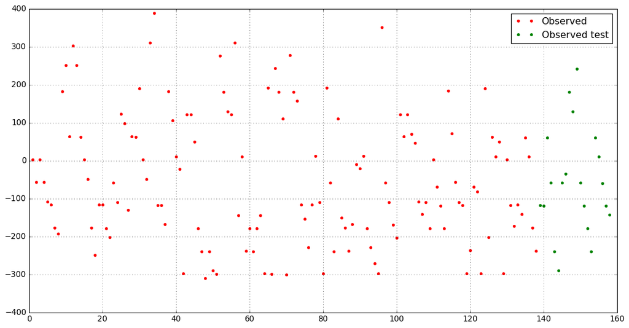

```python
plt.figure(figsize=(16, 8), facecolor='w', edgecolor='k')
plt.grid(True)
plt.plot(data['index'], data['delay'], 'r.', markersize=8, label='Observed')
plt.plot(data_test['index'], data_test['delay'], 'g.', markersize=8, label='Observed test')
plt.legend(loc='best')
plt.show()
```

## Regresión lineal

El primer modelo de predicción que se usará será la regresión lineal. Se procederá a entrenar este modelo con los datos del historico recopilados por el alumno, exceptuando los datos relativos al último día, los datos de test, que se usarán como verificación del modelo.

A continuación se realiza el entrenamiento y se muestran los coeficientes y valores obtenidos para el modelo.

```python
# Create the lineal regression model
regr = linear_model.LinearRegression()

x_train = np.array(data[['index']])
y_train = np.array(data[['delay']])

# Train the model
regr.fit(x_train, y_train)

# Ask the predictions to the model
y_pred = regr.predict(x_train)

print('Coefficients: ', regr.coef_[0])
print('Independent term: ', regr.intercept_)
print('Ecuation: y = ' + str(regr.coef_[0]) + 'X + ' + str(regr.intercept_))

# Mean squared error (the closer to 0.0 the better)
print("Mean squared error: %.2f" % mean_squared_error(y_train, y_pred))
# Variance score (the closer to 1.0 the better)
print('Variance score: %.2f' % r2_score(y_train, y_pred))
```

```
Coefficients:  [-0.72534912]
Independent term:  [2.39448524]
Ecuation: y = [-0.72534912]X + [2.39448524]
Mean squared error: 27793.00
Variance score: 0.03
```

Observando los resultados del entrenamiento pueden observarse que se obtiene un valor medio de error de unos 166 segundos para cada uno de los registros, lo cual es un valor muy alto.

Es posible representar los datos estimados por el modelo junto con los datos de entrenamiento.

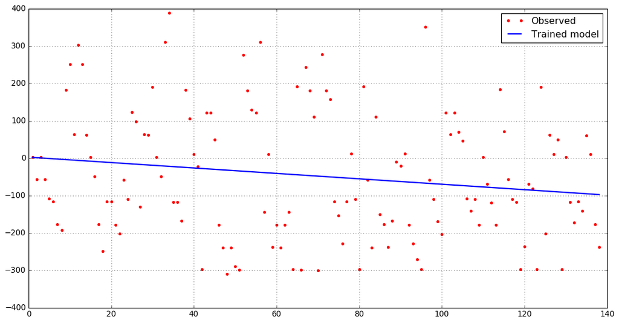

```python
plt.figure(figsize=(16, 8), facecolor='w', edgecolor='k')
plt.grid(True)
plt.plot(data['index'], data['delay'], 'r.', markersize=8, label='Observed')
plt.plot(data['index'], y_pred, lineWidth=2, label='Trained model')
plt.legend(loc='best')
plt.show()
```

El siguiente paso será estimar los valores de retraso para los datos de test. Para ello usamos el modelo de predicción antes entrenado y se calcula el retraso estimados para dichos valores.

```python
predicted_delay = []
for index in data_test['index']:
    predicted_delay.append(regr.predict([[index]])[0][0])

data_test['predicted_a'] = predicted_delay
```

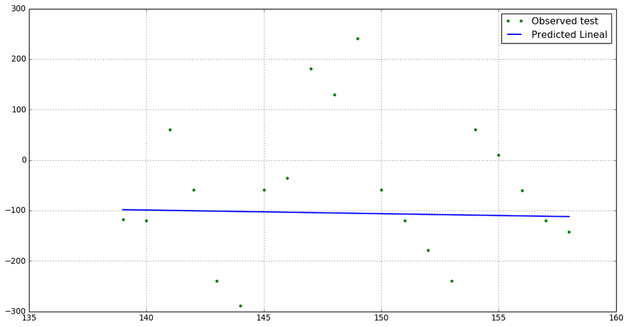

```python
plt.figure(figsize=(16, 8), facecolor='w', edgecolor='k')
plt.grid(True)
plt.plot(data_test['index'], data_test['delay'], 'g.', markersize=8, label='Observed test')
plt.plot(data_test['index'], data_test['predicted_a'], lineWidth=2, label='Predicted Lineal')
plt.legend(loc='best')
plt.show()
```

Por último, es posible ver los datos de entrenamiento junto a los datos de verificación y el ajuste lineal para tener una visión global de lo obtenido.

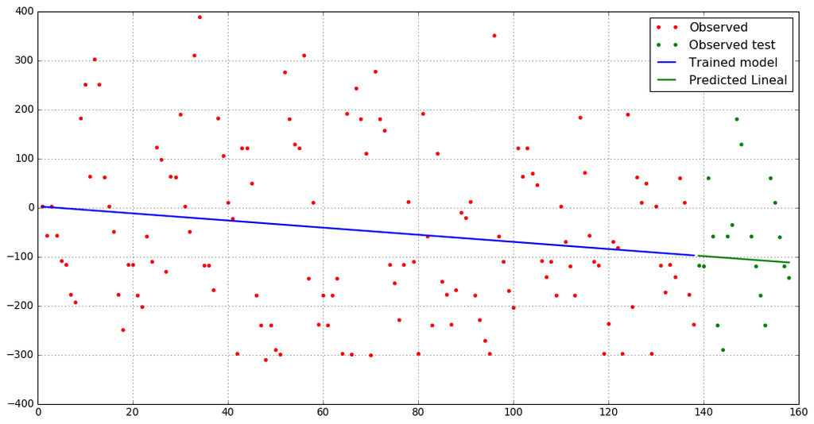

```python
plt.figure(figsize=(16, 8), facecolor='w', edgecolor='k')
plt.grid(True)
plt.plot(data['index'], data['delay'], 'r.', markersize=8, label='Observed')
plt.plot(data_test['index'], data_test['delay'], 'g.', markersize=8, label='Observed test')
plt.plot(data['index'], y_pred, lineWidth=2, label='Trained model')
plt.plot(data_test['index'], data_test['predicted_a'], lineWidth=2, label='Predicted Lineal')
plt.legend(loc='best')
plt.show()
```

Puede verse claramente que el modelo de regresión lineal entrenado no es una buena opción para este conjunto de datos ya que no es capaz de ajustarse a todas las variaciones que tienen los valores.

Además, como ya se ha mencionado antes, el error medio por cada uno de los valores es demasiado alto para ser útil.

## Regresión Gaussiana

```python
from sklearn import gaussian_process
from sklearn.gaussian_process.kernels import Matern, WhiteKernel, ConstantKernel

kernel = ConstantKernel(125) + Matern(length_scale=2, nu=3/2) + WhiteKernel(noise_level=1)

x_train = np.array(data[['index']])
y_train = np.array(data[['delay']])

gp = gaussian_process.GaussianProcessRegressor(kernel=kernel)
gp.fit(x_train, y_train)

y_pred, sigma = gp.predict(x_train, return_std=True)
```

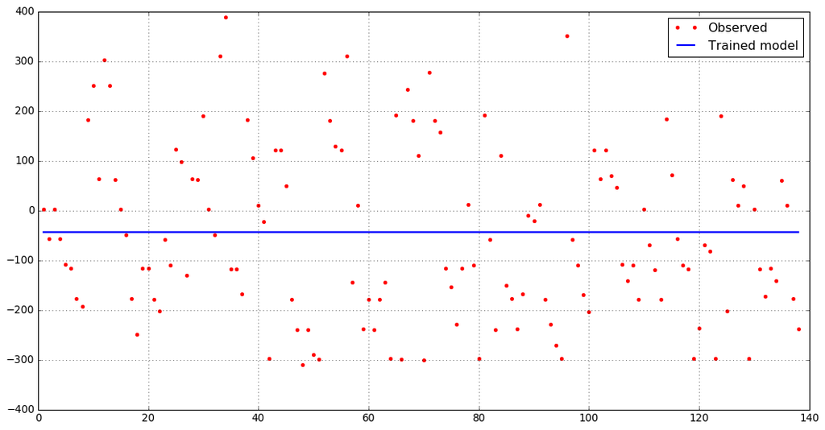

```python
plt.figure(figsize=(16, 8), facecolor='w', edgecolor='k')
plt.grid(True)
plt.plot(data['index'], data['delay'], 'r.', markersize=8, label='Observed')
plt.plot(data['index'], y_pred, lineWidth=2, label='Trained model')
plt.legend(loc='best')
plt.show()
```

```python
predicted_delay = []
for index in data_test['index']:
    predicted_delay.append(gp.predict([[index]])[0][0])

data_test['predicted_b'] = predicted_delay
```

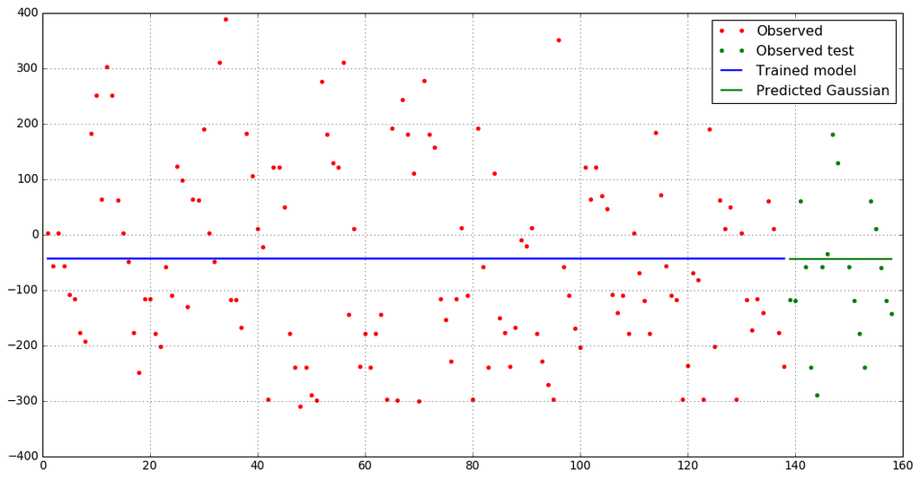

```python
plt.figure(figsize=(16, 8), facecolor='w', edgecolor='k')
plt.grid(True)
plt.plot(data['index'], data['delay'], 'r.', markersize=8, label='Observed')
plt.plot(data_test['index'], data_test['delay'], 'g.', markersize=8, label='Observed test')
plt.plot(data['index'], y_pred, lineWidth=2, label='Trained model')
plt.plot(data_test['index'], data_test['predicted_b'], lineWidth=2, label='Predicted Gaussian')
plt.legend(loc='best')
plt.show()
```

## Serie temporal

Dada la naturaleza de los datos no es dificil verlos como una serie ya que cada uno de los valores tiene su propia marca de tiempo. En este apartado se procederá a crear una serie temporal con todos los datos disponibles para luego realizar un modelo ARIMA sobre los valores de retraso de los autobuses para comprobar si es posible estimarlos de forma satisfactoria.

Para realizar esta tarea, se unirán los conjunto de datos de entrenamiento y prueba para sí disponer de más información para este modelo.

```python
data_temporal = data[['index', 'date', 'delay']].append(data_test[['index', 'date', 'delay']], sort=True, ignore_index=True)
```

A continuación pasamos a representar la serie tiempo para visualizarla.

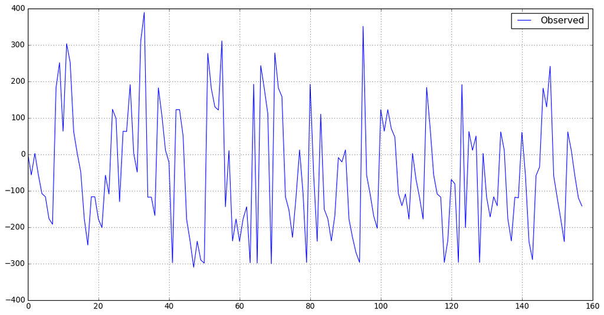

```python
plt.figure(figsize=(16, 8), facecolor='w', edgecolor='k')
plt.grid(True)
plt.plot(data_temporal['delay'], label='Observed')
plt.legend(loc='best')
plt.show()
```

También es posible aplicar un filtro a los datos para obtener la tendencia de los mismos.

```python
data_cicle, data_tend = sm.tsa.filters.hpfilter(data['delay'])
data_temporal['tend'] = data_tend
```

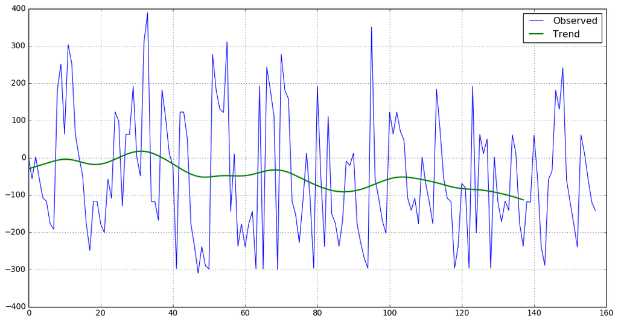

```python
plt.figure(figsize=(16, 8), facecolor='w', edgecolor='k')
plt.grid(True)
plt.plot(data_temporal['delay'], label='Observed')
plt.plot(data_temporal['tend'], lineWidth=2, label='Trend')
plt.legend(loc='best')
plt.show()
```

Descomponer la serie temporal para observar con más detalles cada una de sus componentes puede ser una buena idea para estudiarla con más detalle. Se asume que la serie temporal es de tipo aditivo ya que posee valores negativos y muy cercanos a cero, por lo que el modelo multiplicativo queda descartado.

```python
descomposition = sm.tsa.seasonal_decompose(data_temporal['delay'], model='additive', freq=15)
```

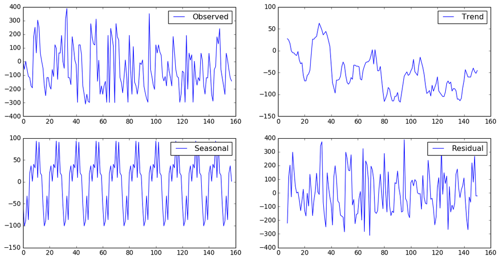

```python
plt.figure(figsize=(16, 8), facecolor='w', edgecolor='k')
plt.grid(True)

plt.subplot(221)
plt.plot(data_temporal['delay'], label='Observed')
plt.legend()

plt.subplot(222)
plt.plot(descomposition.trend, label='Trend')
plt.legend()

plt.subplot(223)
plt.plot(descomposition.seasonal, label='Seasonal')
plt.legend()

plt.subplot(224)
plt.plot(descomposition.resid, label='Residual')
plt.legend()

plt.show()
```

Una vez visualizada la serie temporal puede estudiarse con un poco más de facilidad.

Se procede a crear un modelo ARIMA para este conjunto de datos y ver cómo de bien le es posible estimar los valores.

```python
model = sm.tsa.ARIMA(data_temporal['delay'].iloc[1:], order=(1, 0, 0))
result = model.fit(disp=-1)
data_temporal['fitted_arima'] = result.fittedvalues
```

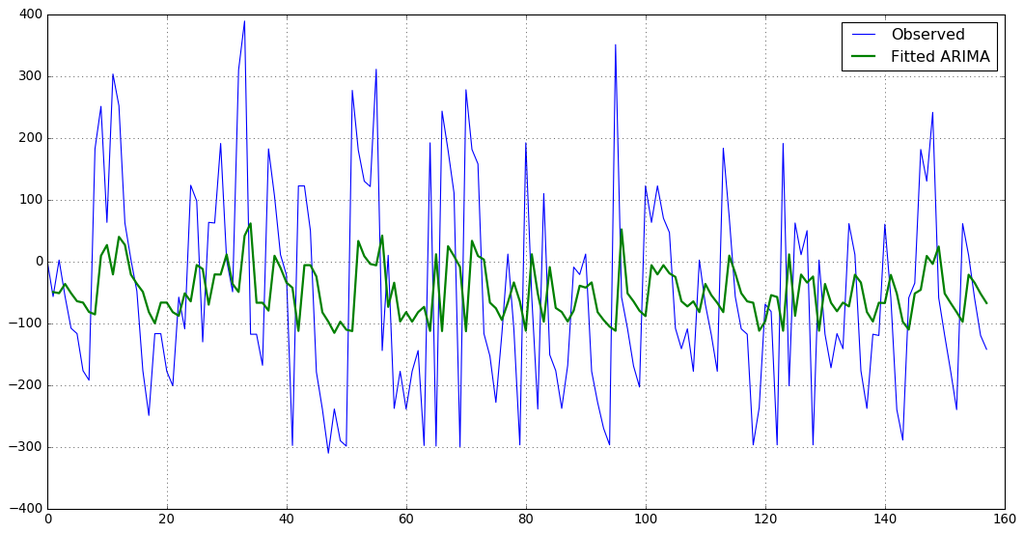

```python
plt.figure(figsize=(16, 8), facecolor='w', edgecolor='k')
plt.grid(True)
plt.plot(data_temporal['delay'], label='Observed')
plt.plot(data_temporal['fitted_arima'], lineWidth=2, label='Fitted ARIMA')
plt.legend(loc='best')
plt.show()
```

Puede verse claramente que las predicciones realizadas por el model ARIMA no son capaces de ajuste a los cambios de la función original. Por este motivo tampoco es una buena aproximación.

A continuación se realizará un test de Dickey-Fuller para comprobar la estacionalidad de la serie. Se declarrá una función para esta tarea porque se requerirá varias veces su ejecución.

```python
def testStationality(time_series, title):
    moving_avg = time_series.rolling(15).mean()
    moving_std = time_series.rolling(15).std()

    plt.figure(figsize=(16, 8), facecolor='w', edgecolor='k')
    plt.grid(True)
    plt.plot(time_series, label=title)
    plt.plot(moving_avg, lineWidth=2, label='Rolling mean')
    plt.plot(moving_std, lineWidth=2, label='Rolling std')
    plt.legend(loc='best')
    plt.show()

    print ('Results of Dickey-Fuller test 1:')
    dftest = adfuller(time_series, autolag='AIC')
    dfoutput = pd.Series(dftest[0:4], index=['Test Statistic','p-value','# Lags used','Number of bbservations used'])
    for key,value in dftest[4].items():
        dfoutput['Critical Value (%s)'%key] = value
    print (dfoutput)
```

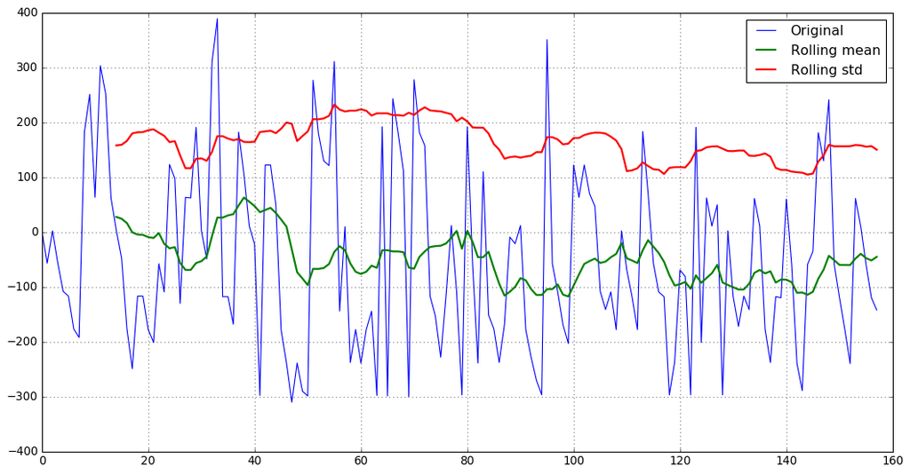

```
Results of Dickey-Fuller test 1:
Test Statistic                -9.587897e+00
p-value                        2.073454e-16
# Lags used                    0.000000e+00
Number of bbservations used    1.570000e+02
Critical Value (1%)           -3.472703e+00
Critical Value (5%)           -2.880132e+00
Critical Value (10%)          -2.576683e+00
dtype: float64
```

```python
testStationality(data_temporal['delay'], 'Original')
```

Puede observarse por el valor `p-value` que la serie está muy cerca de ser estacionaria.

Vamos a intentar hacer la serie más estacionaria si es posible aplicando algunas transformaciones. Comenzaremos con aplicar 'La primera diferencia'.

```python
data_temporal['first_diference'] = data_temporal['delay'] - data_temporal['delay'].shift(1)
```

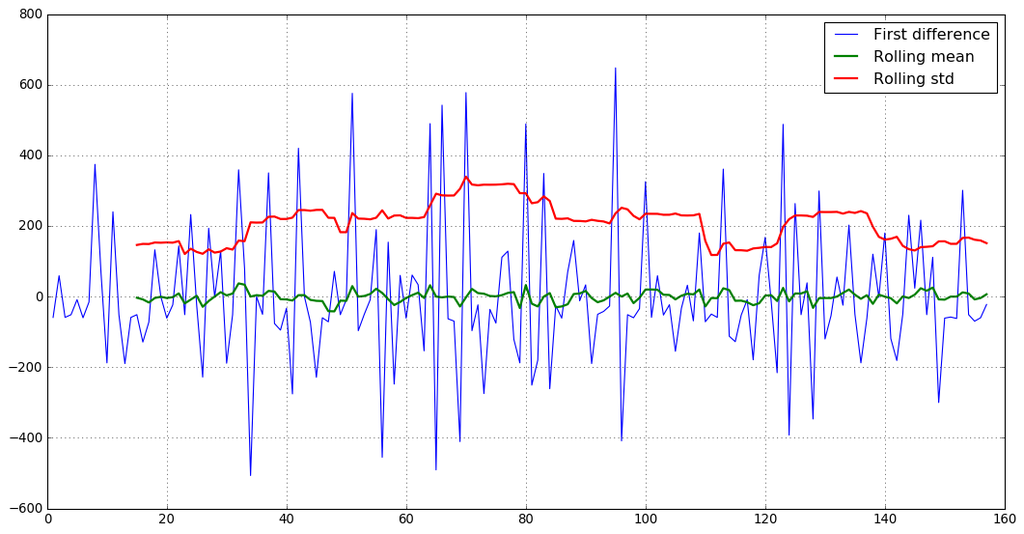

```
Results of Dickey-Fuller test 1:
Test Statistic                -7.507951e+00
p-value                        4.087049e-11
# Lags used                    1.100000e+01
Number of bbservations used    1.450000e+02
Critical Value (1%)           -3.476273e+00
Critical Value (5%)           -2.881688e+00
Critical Value (10%)          -2.577513e+00
dtype: float64
```

```python
testStationality(data_temporal['first_diference'].dropna(inplace=False), 'First difference')
```

Claramente esto ha empeorado la estacionalidad de los datos.

Para finalizar, se procede a realizar un diferencia estacional para eliminar la estacionalidad de los datos y ver como afecta esto a los datos originales.

```python
data_temporal['seasonal_difference'] = data_temporal['delay'] - data_temporal['delay'].shift(15)
```

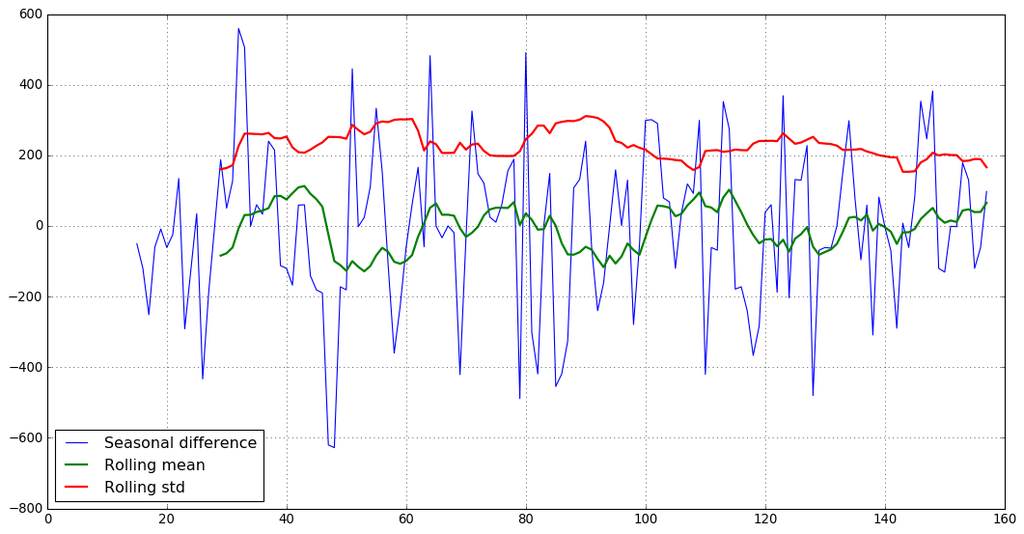

```
Results of Dickey-Fuller test 1:
Test Statistic                  -5.320992
p-value                          0.000005
# Lags used                     14.000000
Number of bbservations used    128.000000
Critical Value (1%)             -3.482501
Critical Value (5%)             -2.884398
Critical Value (10%)            -2.578960
dtype: float64
```

```python
testStationality(data_temporal['seasonal_difference'].dropna(inplace=False), 'Seasonal difference')
```

Puede verse en el valor de `p-value` que no merece la pena continuar, ya que se están empeorando los valores originales.

El siguiente paso, ya que se ha comprobado que la serie es estacionaria es crear un modelo de predicción SARIMAX.

Para realizar algunas predicciones futuras se va proceder a aumentar en 22 registros el DataFrame, de modo que haya espacio vacio al final.

```python
size = data_temporal.shape[0]
future_index = np.linspace(size + 1, size + 22, 22)

for index in future_index:
    s = pd.Series(index, index=['index'])
    data_temporal = data_temporal.append(s, ignore_index=True)
```

Una vez que el conjunto de datos está listo, se procede a entrenar el modelo.

```python
model = sm.tsa.statespace.SARIMAX(data_temporal['delay'], trend='n', order=(0,1,0), seasonal_order=(1,1,1,12))
results = model.fit()
data_temporal['fitted_sarimax'] = result.fittedvalues
data_temporal['forecast_sarimax'] = results.predict(start = 140, end= 158, dynamic= True)
data_temporal['forecast_sarimax_future'] = results.predict(start = 159, end= 180, dynamic= True)
```

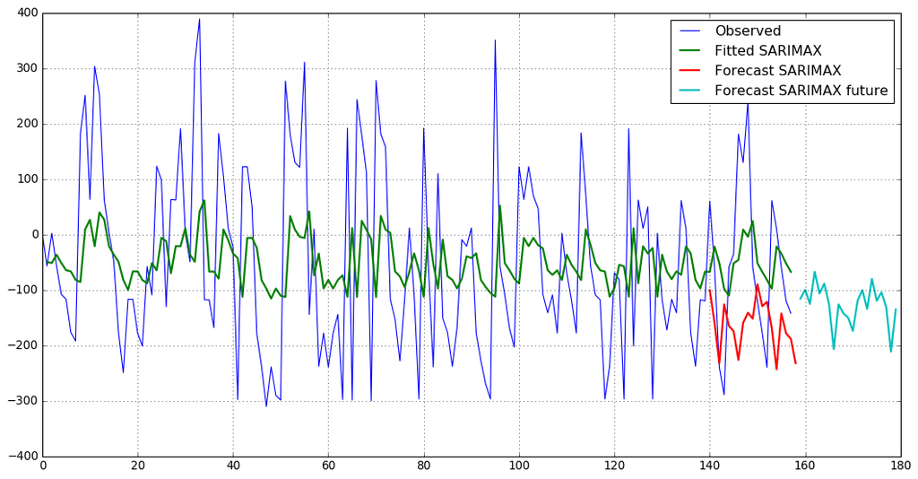

```python
plt.figure(figsize=(16, 8), facecolor='w', edgecolor='k')
plt.grid(True)
plt.plot(data_temporal['delay'], label='Observed')
plt.plot(data_temporal['fitted_sarimax'], lineWidth=2, label='Fitted SARIMAX')
plt.plot(data_temporal['forecast_sarimax'], lineWidth=2, label='Forecast SARIMAX')
plt.plot(data_temporal['forecast_sarimax_future'], lineWidth=2, label='Forecast SARIMAX future')
plt.legend(loc='best')
plt.show()
```

Tal y como puede observarse, los datos predichos se alejan bastante de la realidad ya que el modelo no es capaz de adaptarse a la gran variación que tienen los datos.